## shinyVenn使用说明

shinyVenn是一个基于R/shiny应用程序，用于绘制venn图。本文档可以解决用户遇到的一些常见问题

### 这是什么

> A Venn diagram is a diagram that shows all possible logical relations between a finite collection of different sets.

### 如何使用

在venn diagrame 选项下您可以在左侧菜单中点击“data”按钮选择上传数据的方式 在这里您可以使用：  
1.点击“Upload data”以txt文本的方式上传  
2.点击“Paste input data”直接将数据输入到对话框中  
3.对生成的图片进行个性化设置

当您上传所有数据以后，点击GO按钮生成图片  
注：  
1.您可以选择上传数据组的个数，这里支持最多七组  
2.**无论您以何种方式上传数据，我们都需要以每个元素占一行的格式上传**  
例如

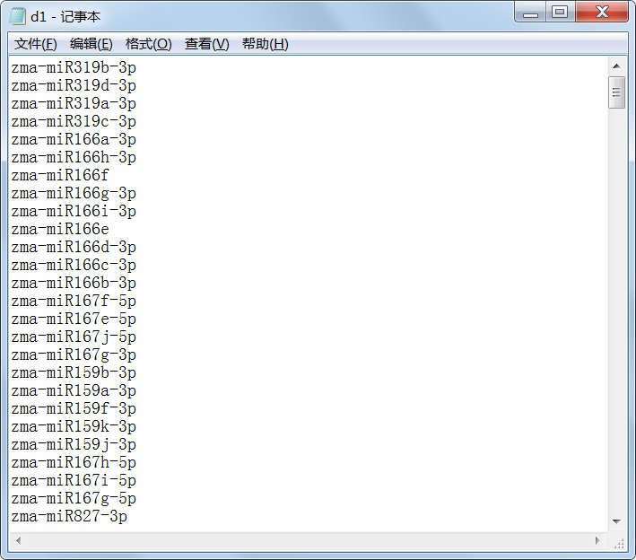

[figure not shown]

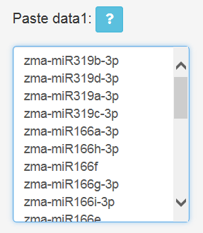

3.同时我们支持个性化的调试图片的大小，颜色，图片中文字大小等内容

### 网络使用：

http://150.109.59.144:3838/shinyVenn/